# chemmodlab Quickstart Tutorial

Jeremy Ash

2017-01-25

## Installation

Use the code below to install the package. Since you are installing from source, you will need to install the package dependencies manually. This will be done automatically once this is accepted by CRAN.

```r
install.packages(c("class", "e1071", "elasticnet", "foreach", "lars", "MASS",
                   "nnet", "pROC", "randomForest", "rpart", "tree", "pls"))

install.packages("path/to/chemmodlab_0.0.0.9000.tar.gz",
                 repos = NULL, type = "source")
```

First we construct the data set. The data should be a a data frame containing an (optional) ID column, a response column, and descriptor columns. The columns should be provide in this order.

The response is a binary variable indicating whether the compound is active or not. At the moment chemmodlab only supports responses that are binary (represented as a numeric vector with 0 or 1 values) or continuous.

## Data Preprocessing

```r
data <- read.csv("AID_364_response.csv")
head(data)
```

```
##        CID Outcome
## 1  5388992       1
## 2  5388983       1
## 3   663143       1
## 4    10607       1
## 5  5388972       1
## 6 11970251       1
```

Next we add two descriptor sets to the data frame. At the moment, only numeric descriptors are supported. We store the number of descriptors in each descriptor set, as this will be used to parse the data frame later.

```r
desc.lengths <- c()
d <- read.csv("BurdenNumbers.csv")
head(d[, 1:5])
```

```
##        Row WBN_GC_L_0.25 WBN_GC_H_0.25 WBN_GC_L_0.50 WBN_GC_H_0.50
## 1  5388992      -2.40010       1.98339      -2.52864       2.50835
## 2  5388983      -2.40010       1.98240      -2.52868       2.50398
## 3   663143      -2.41650       1.32890      -2.53910       2.05778
## 4    10607      -2.38337       2.17677      -2.52643       2.33232
## 5  5388972      -2.29039       1.97468      -2.41743       2.46177
## 6 11970251      -2.29039       2.22488      -2.41748       2.56161
```

```r
data <- cbind(data, d[-1])
desc.lengths <- c(desc.lengths, ncol(d[-1]))

d <- read.csv("Pharmacophores.csv")
head(d[, 1:6])
```

```
##        Row NEG_01_NEG NEG_02_NEG NEG_03_NEG NEG_04_NEG NEG_05_NEG
## 1  5388992          0          0          0          0          0
## 2  5388983          0          0          0          0          0
## 3   663143          0          0          0          0          0
## 4    10607          0          0          0          0          0
## 5  5388972          0          0          0          0          0
## 6 11970251          0          0          0          0          0
```

```r
data <- cbind(data, d[-1])
desc.lengths <- c(desc.lengths, ncol(d[-1]))

dim(data)
```

```
## [1] 3311  173
```

For this example, we make the data set smaller so the model fitting will run faster.

```r
aid364 <- data[1:500, ]
```

## Model Fitting

The data is ready to analyze. We use the default set of models, number of cross validation folds, etc. See `?ModelTrain` for more details. In all the output, we will name the descriptor sets “BurdenNumbers” and “Pharmacophores”. The function will complain about some colinear variables, do not worry about this at the moment.

```r
library(chemmodlab)
cml <- ModelTrain(aid364, ids = T, xcol.lengths = desc.lengths,
                  des.names = c("BurdenNumbers", "Pharmacophores"))
```

## Comparison of Model Performance

### Accumulation Curves

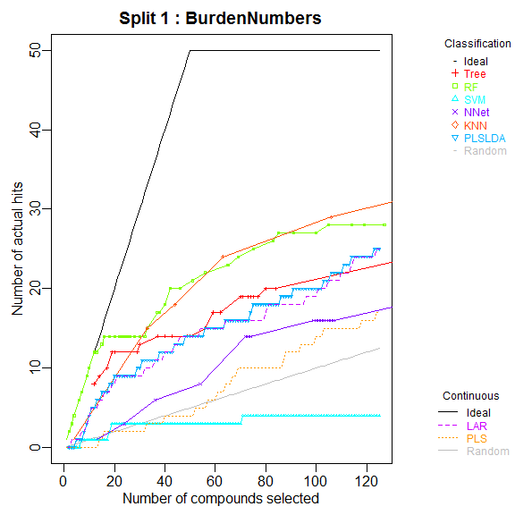

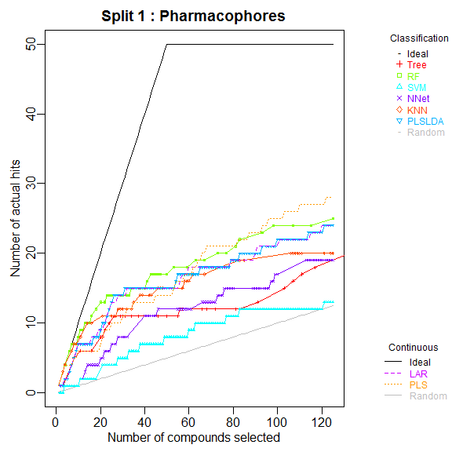

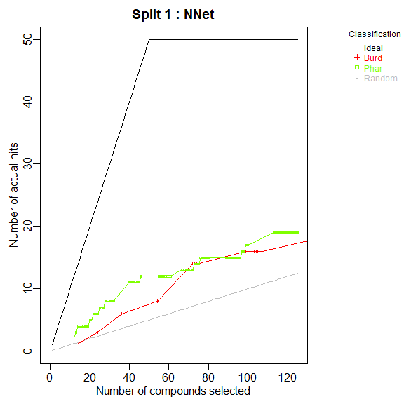

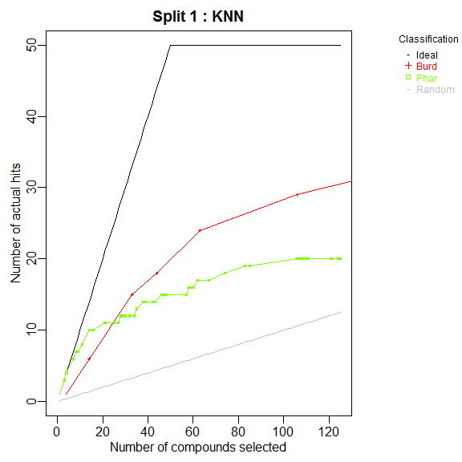

```r
plot(cml, splits = 1, models = c("NNet", "KNN"))
```

### Multiple Comparisons Plots

Finally, we compare model performance with the multiple comparisons plot. Here we are using the default model assessment measure (intial enhancement at 300 tests).[^1] See `?CombineSplits` for more information

```r
CombineSplits(cml)
```

```
##    Analysis of Variance on: 'enhancement'
##  Using factors: Split and Descriptor/Method combination
## Source    DF         SS         MS          F   p-value
## Model     17   10.38373    0.61081   20.96606    <.0001
## Error     30    0.87399    0.02913
## Total     47   11.25772
##       R-Square   Coef Var   Root MSE       Mean
##         0.9224     9.9545     0.1707     1.7147
## Source       DF        SS        MS         F   p-value
## Split         2    0.1527    0.0764    2.6207    0.0783
## Desc/Meth    15   10.2310    0.6821   23.4121    <.0001
```

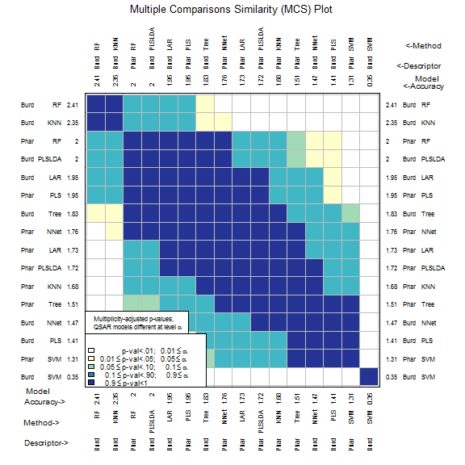

We can also assess models using a number of other assessment measures

```r
CombineSplits(cml, metric = "error rate")
```

```
##    Analysis of Variance on: 'error rate'
##  Using factors: Split and Descriptor/Method combination
## Source    DF          SS          MS           F   p-value
## Model     17   3.451e+00   2.030e-01   5.298e+03    <.0001
## Error     30   1.150e-03   3.832e-05
## Total     47   3.452e+00
##       R-Square   Coef Var   Root MSE       Mean
##        0.99967    2.96588    0.00619    0.20871
## Source       DF         SS         MS          F   p-value
## Split         2   2.13e-04   1.07e-04   2.78e+00    0.0685
## Desc/Meth    15   3.45e+00   2.30e-01   6.00e+03    <.0001
```

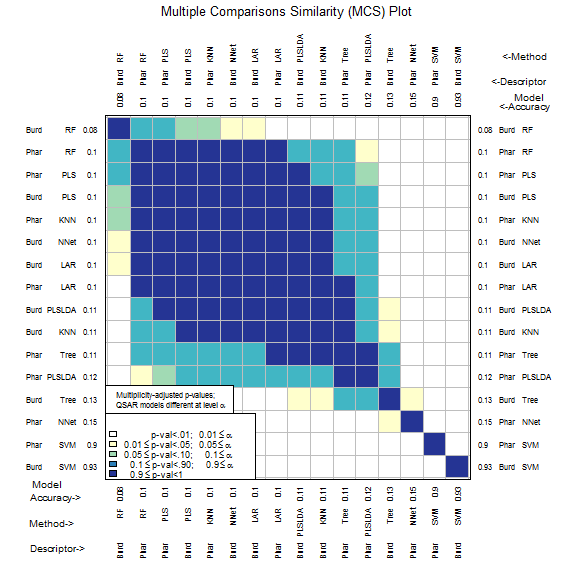

```r
CombineSplits(cml, metric = "sensitivity")
```

```
##    Analysis of Variance on: 'sensitivity'
##  Using factors: Split and Descriptor/Method combination
## Source    DF          SS          MS           F   p-value
## Model     17   3.130e+00   1.841e-01   1.740e+02    <.0001
## Error     30   3.175e-02   1.058e-03
## Total     47   3.161e+00
##       R-Square   Coef Var   Root MSE       Mean
##         0.9900    16.1316     0.0325     0.2017
## Source       DF         SS         MS          F   p-value
## Split         2   2.12e-03   1.06e-03   1.00e+00    0.3451
## Desc/Meth    15   3.13e+00   2.09e-01   1.97e+02    <.0001
```

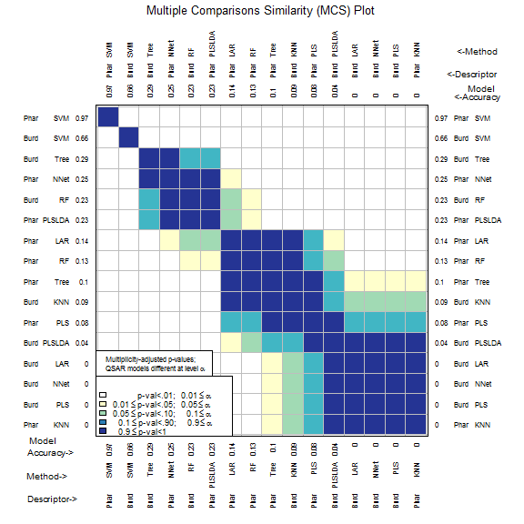

```r
CombineSplits(cml, metric = "specificity")
```

```
##    Analysis of Variance on: 'specificity'
##  Using factors: Split and Descriptor/Method combination
## Source    DF          SS          MS           F   p-value
## Model     17   5.037e+00   2.963e-01   6.269e+03    <.0001
## Error     30   1.418e-03   4.726e-05
## Total     47   5.039e+00
##       R-Square   Coef Var   Root MSE       Mean
##        0.99972    0.80238    0.00687    0.85681
## Source       DF         SS         MS          F   p-value
## Split         2   1.52e-04   7.62e-05   1.61e+00    0.1909
## Desc/Meth    15   5.04e+00   3.36e-01   7.11e+03    <.0001
```

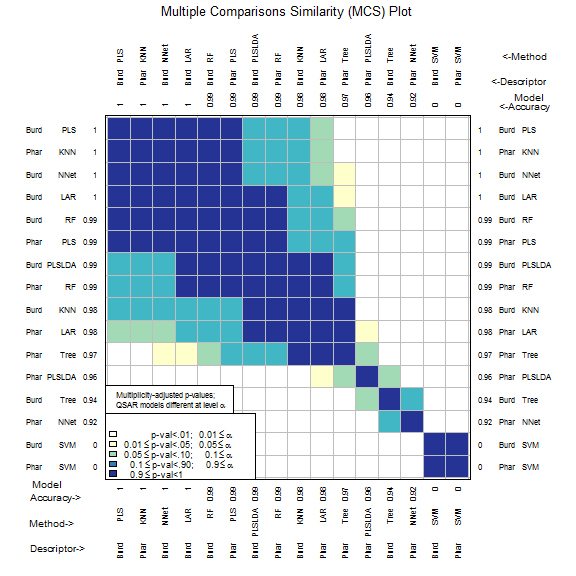

```r
CombineSplits(cml, metric = "auc")
```

```
##    Analysis of Variance on: 'auc'
##  Using factors: Split and Descriptor/Method combination
## Source    DF          SS          MS           F   p-value
## Model     17   1.502e-01   8.835e-03   1.237e+01    <.0001
## Error     30   2.143e-02   7.142e-04
## Total     47   1.716e-01
##       R-Square   Coef Var   Root MSE       Mean
##         0.8751     3.9567     0.0267     0.6754
## Source       DF         SS         MS          F   p-value
## Split         2    0.00284    0.00142    1.98910    0.1354
## Desc/Meth    15    0.14735    0.00982   13.75313    <.0001
```

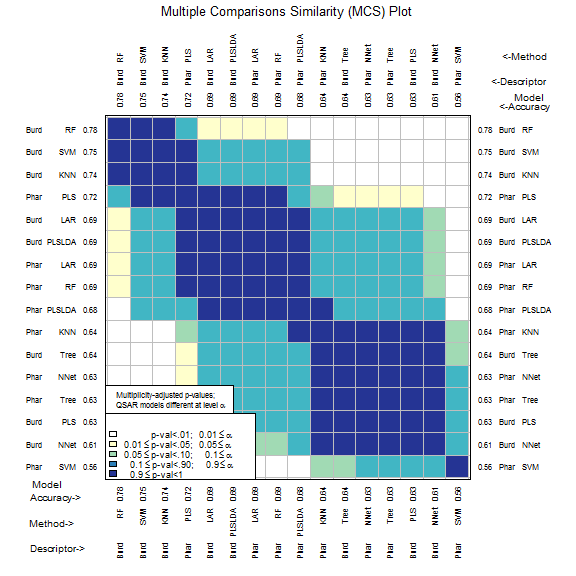

[^1]: I am aware that while the plots look good in this vignette, the plotting window in the user’s r environment needs to be quite large for these plots to be visible. I am working on improving this at the moment.